# Project1 - Spooky Analysis

# Section 3: Vocabulary

## 3.1 - Word frequency and TF-IDF

```r
# #### CODE FROM THE IN-CLASS TUTORIAL ####
# Words is a list of words, and freqs their frequencies
words <- count(group_by(spooky_wrd, word))$word
freqs <- count(group_by(spooky_wrd, word))$n
# head(sort(freqs, decreasing = TRUE))
# wordcloud(words, freqs, max.words = 50, color = c("purple4", "red4", "black"))
```

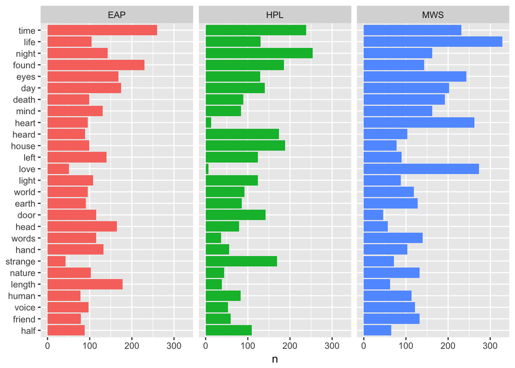

```r
# #### CODE FROM THE IN-CLASS TUTORIAL ####
# Counts number of times each author used each word.
author_words <- count(group_by(spooky_wrd, word, author))

# Counts number of times each word was used.
all_words    <- rename(count(group_by(spooky_wrd, word)), all = n)

author_words <- left_join(author_words, all_words, by = "word")
author_words <- arrange(author_words, desc(all))
author_words <- ungroup(head(author_words, 81))

ggplot(author_words) +
  geom_col(aes(reorder(word, all, FUN = min), n, fill = author)) +
  xlab(NULL) +
  coord_flip() +
  facet_wrap(~ author) +
  theme(legend.position = "none")
```

## 3.2 - TF-IDF with lemmas

We can compute TF-IDF and perform the same analysis on lemmas instead of words. Some lemmas that are not represented in the top words plotted above may appear, because they were split into too many different words before.

Yet, I have performed this analysis, which gives the same results, and therefore the code is not shown is this notebook.

## 3.3 - Names

### 3.3.1 - Use of names

```r
# We have reduced author_words to the most frequent words, we must therefore recreate it here:
author_words <- count(group_by(spooky_wrd, word, author))

is.name <- function(word) word %in% common_names
author_words$is_name <- is.name(author_words$word)
author_words %>% group_by(author) %>% summarise(sum(is_name))
```

```
## # A tibble: 3 x 2
##   author `sum(is_name)`
##   <chr>           <int>
## 1 EAP               306
## 2 HPL               318
## 3 MWS               220
```

```r
author_words %>% group_by(author) %>% summarise(mean(is_name))
```

```
## # A tibble: 3 x 2
##   author `mean(is_name)`
##   <chr>            <dbl>
## 1 EAP             0.0206
## 2 HPL             0.0224
## 3 MWS             0.0198
```

We can see that HP Lovecraft uses slightly more names than the other authors. Yet, we need to be very careful with this analysis: First, our dataset is from 1990, therefore might not contain some names that were used at the time these texts were written. Also, we only look at first names, but the authors may use last name quite often (“Mr. xxx” …); if we assumed that all authors use “names” in general (ie first names or last names) as frequently, then we could conclude that HP Lovecraft uses first names more than the two other authors who use last names more. Yet, we do not know yet the distributions of names in general. Lastly, the authors might use fictionnal first names that are not present in our dataset but might also not be in an older census.

We’ll have a more general approach on names in Section 4 when we will do Part of Speech, which identifies last names, fictionnal names, old names, etc.

## 3.4 - Diversity of the vocabulary

Let’s look at how the authors use the diversity of the english vocabulary.

### 3.4.1 - Size of author’s vocabulary

How many different (unique) words does each author use ?

```r
EAP_words_count <- spooky_wrd[spooky_wrd$author == 'EAP',] %>% group_by(word) %>% summarise(count = n())
HPL_words_count <- spooky_wrd[spooky_wrd$author == 'HPL',] %>% group_by(word) %>% summarise(count = n())
MWS_words_count <- spooky_wrd[spooky_wrd$author == 'MWS',] %>% group_by(word) %>% summarise(count = n())

# nb of unique words / total nb of words used:
dim(EAP_words_count)[1] / dim(spooky_wrd[spooky_wrd$author == 'EAP',])[1]
```

```
## [1] 0.2039427
```

```r
dim(HPL_words_count)[1] / dim(spooky_wrd[spooky_wrd$author == 'HPL',])[1]
```

```
## [1] 0.2274775
```

```r
dim(MWS_words_count)[1] / dim(spooky_wrd[spooky_wrd$author == 'MWS',])[1]
```

```
## [1] 0.1778628
```

```r
 # how many times is a word used on average
mean(EAP_words_count$count)
```

```
## [1] 4.903339
```

```r
mean(HPL_words_count$count)
```

```
## [1] 4.396039
```

```r
mean(MWS_words_count$count)
```

```
## [1] 5.622312
```

We can see that Mary Shelly has a poorer vocabulary, ie she has a smaller core vocabulary and uses the same words often.

### 3.4.2 - Made up words / Old words

Let’s look at whether the words that our three authors used are present in a modern dictionnary. This will tell us two things: first, if the authors tend to use made up words (which they are known to do, see: https://blog.oxforddictionaries.com/2014/08/20/inventive-words-worlds-edgar-allan-poe-h-p-lovecraft/); also, whether they use relatively old words that are no longer in a modern dictionnary (which we woud expect more from Mary Shelley and Edgar Allan Poe, who lived almost a century before HP Lovecraft).

We use the dictionnary GradyAugmented from the lexicon package, which is a very large dataset of 120,000 words, therefore quite extensive, of english words.

```r
is.word  <- function(x) x %in% GradyAugmented # or use any dataset from package
author_words <- count(group_by(spooky_wrd, word, author))
author_words$exists <- is.word(author_words$word)
author_words %>% group_by(author) %>% summarise(mean(exists)) # percentage of words per author that are in dictionnary
```

```
## # A tibble: 3 x 2
##   author `mean(exists)`
##   <chr>           <dbl>
## 1 EAP             0.858
## 2 HPL             0.854
## 3 MWS             0.916
```

We can see that Mary Shelley uses 6 % more words that are in our dictionnary. This is not surprising at all ! Edgar Allan Poe and HP Lovecraft are known for this (see link above), and actually created words that are now used commonly, which we could observe if we had a dataset of words from the 19th century (which I haven’t been able to find unfortunately).

## 3.5 - Male vs Female representation

The last analysis is on how and how often are men and women represented by the three authors. The goal is to find whether some author speak more about men or women, if they make them do or say particular things, if women speak more about emotions etc.

### 3.5.1 - Her vs She:

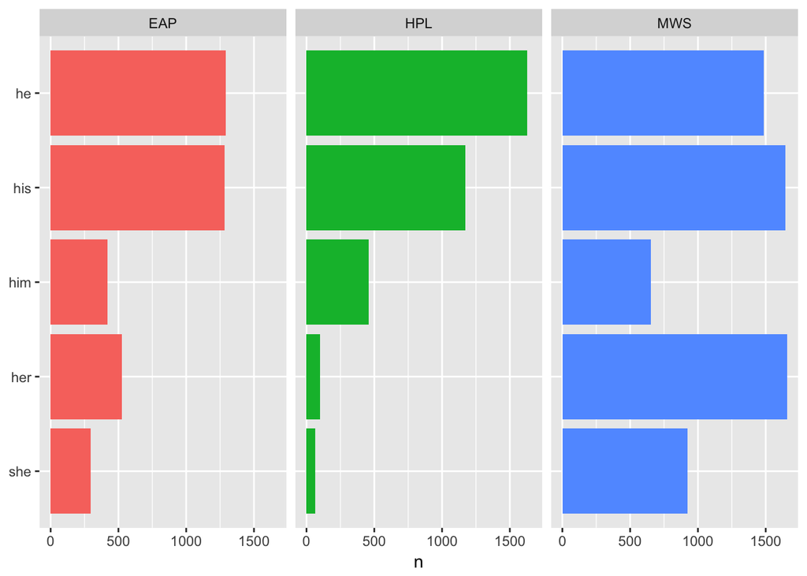

```r
author_words_with_stopwords <- count(group_by(spooky_wrd_with_stopwords, word, author))
male_female_word_counts <- author_words_with_stopwords[author_words_with_stopwords$word %in% c('he', 'she', 'him', 'her', 'his'),]

ggplot(male_female_word_counts) +
  geom_col(aes(reorder(word, n, FUN = min), n, fill = author)) +
  xlab(NULL) +
  coord_flip() +
  facet_wrap(~ author) +
  theme(legend.position = "none")
```

We can see a clear difference between the authors: Edgar Allan Poe and HP Lovecraft seem to refer more often to men than to women, whereas it is much less the case for Mary Shelly which uses almost as often female pronouns than male pronouns.

### 3.5.2 - Bi-grams male vs female

Since we have computed bi-grams, let’s look at what words typically follow the pronoun “he” vs the pronoun “she”, which will tell us about actions or feelings that men and women have or do in each author’s work.

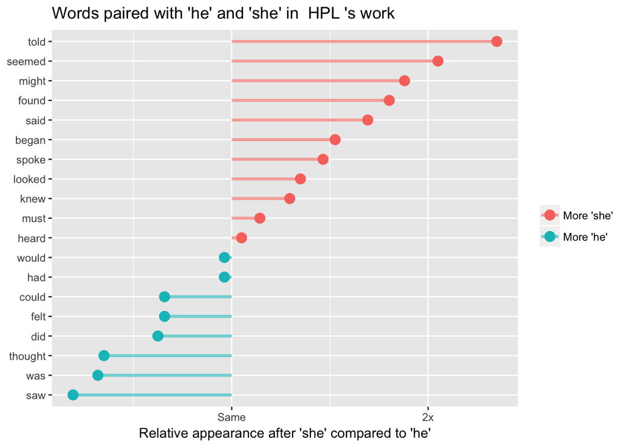

```r
plot_male_female <- function(author) {
      pronouns <- c("he", "she")
    bigram_counts <- spooky_bigrams[spooky_bigrams$author == author,] %>%
        count(bigram, sort = TRUE) %>%
        separate(bigram, c("word1", "word2"), sep = " ") %>%
        filter(word1 %in% pronouns) %>%
        count(word1, word2, wt = n, sort = TRUE) %>%
        rename(total = nn)

    bigram_counts

    word_ratios <- bigram_counts %>%
        group_by(word2) %>%
        filter(sum(total) > 10) %>%
        ungroup() %>%
        spread(word1, total, fill = 0) %>%
        mutate_if(is.numeric, funs((. + 1) / sum(. + 1))) %>%
        mutate(logratio = log2(she / he)) %>%
        arrange(desc(logratio))

    word_ratios %>%
        arrange(abs(logratio))

    word_ratios %>%
        mutate(abslogratio = abs(logratio)) %>%
        group_by(logratio < 0) %>%
        top_n(15, abslogratio) %>%
        ungroup() %>%
        mutate(word = reorder(word2, logratio)) %>%
        ggplot(aes(word, logratio, color = logratio < 0)) +
        geom_segment(aes(x = word, xend = word,
                         y = 0, yend = logratio),
                     size = 1.1, alpha = 0.6) +
        geom_point(size = 3.5) +
        coord_flip() +
        labs(x = NULL,
             y = "Relative appearance after 'she' compared to 'he'",
             title = paste("Words paired with 'he' and 'she' in ", author, "'s work")) +
        scale_color_discrete(name = "", labels = c("More 'she'", "More 'he'")) +
        scale_y_continuous(breaks = seq(-3, 3),
                           labels = c("0.125x", "0.25x", "0.5x",
                                      "Same", "2x", "4x", "8x"))
}

plot_male_female("HPL")
```

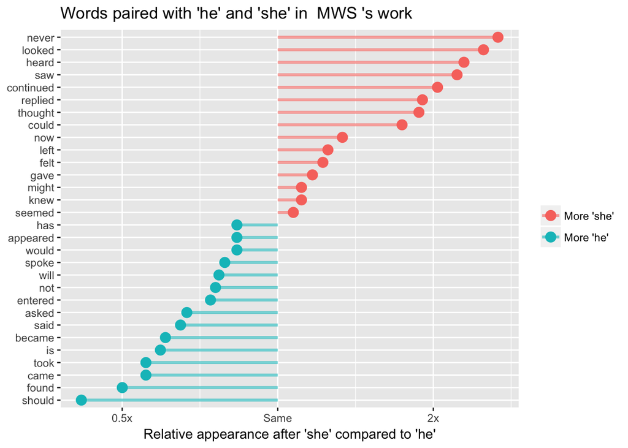

```r
plot_male_female("MWS")
```

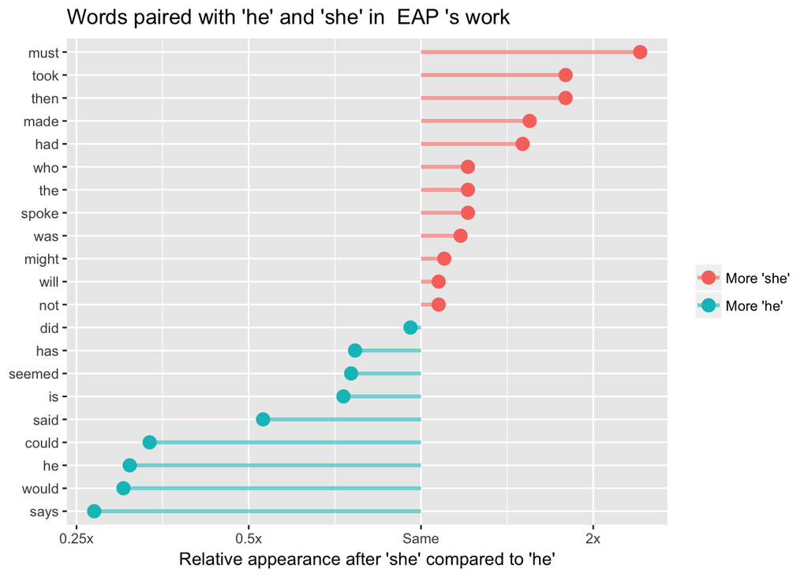

```r
plot_male_female("EAP")
```

# Section 4: Sentence structure

In this last section, we look at the functions of words or groups of words rather than words themselves, ie we look at structures of sentences and not vocabulary itself.

## 4.1 - Dialogue

First, let’s look at how often do the authors use dialogue. To do so, we’ll spot quotation marks “xxx” to identify sentences as containing dialogues.

```r
spooky <- cbind(spooky, dialogue = mapply(function(x) str_count(x, '\\"'), spooky$text))
aggregate(dialogue ~ author, spooky, mean)
```

```
##   author   dialogue
## 1    EAP 0.37594081
## 2    HPL 0.09110358
## 3    MWS 0.24339591
```

## 4.2 - Entities

Let’s now look at how often entities are mentioned in the text, and in particular persons. This will extend the basic approach that we had in Section 3, where we looked at words that were names. Here, we look at the sentences to identify if words are entities, using a Part-of-speech tagger. This technique is far more precise since it doesn’t rely on a particular dataset of names. As for lemmatization, entity recognition is quite expensive and takes some time to run. [NOTE: On Mac OS X, you might have trouble running this due to some extra steps needed to run rJava. See Section 0.]

```r
sent_token_annotator <- Maxent_Sent_Token_Annotator()
word_token_annotator <- Maxent_Word_Token_Annotator()
entity_annotator <- Maxent_Entity_Annotator(kind="person")

contains_entity <- function(s) {
  a2 <- annotate(s, list(sent_token_annotator, word_token_annotator))
  a3 <- annotate(s, entity_annotator, a2)
  length(subset(a3, type == "entity")) > 0
}

spooky <- cbind(spooky, has_entity = mapply(contains_entity, spooky$text))
aggregate(has_entity ~ author, spooky, mean) # HPL and MWS use more entities
```

```
##   author has_entity
## 1    EAP 0.05191989
## 2    HPL 0.08628989
## 3    MWS 0.08954976
```

We can see that HP Lovecraft and Mary Shelly use 3 % more entities than Edgar Allan Poe. This result is quite surprising, given that we saw earlier that Edgar Allan Poe uses dialogue more often, and we would expect sentences containing dialogue to be more likely contain entities. Yet, our analysis on dialogue was quite unprecise (depends on the data collection and preprocessing that generated the csv…).

## 4.3 - Full Part-of-Speech tagging:

The ultimate analysis that we’ll do is to fully tag the sentences with the part-of-speech tagger that we just used for entities. This will give great insight on how the authors construct their sentences.

### 4.3.1 - Split into tags

```r
pos_tag_annotator <- Maxent_POS_Tag_Annotator()

posify <- function(s) {
  # given a string, replaces each word by corresponding POS tag
  a1 <- annotate(s, list(sent_token_annotator, word_token_annotator))
  a2 <- annotate(s, pos_tag_annotator, a1)
  tags <- sapply(a2$features, `[[`, "POS")
  do.call(paste, c(as.list(tags), sep=" "))
}

spooky <- cbind(spooky, pos = mapply(posify, spooky$text), stringsAsFactors=FALSE)
spooky_pos <- unnest_tokens(spooky, tag, pos)
```

### 4.3.2 - Tags frequency:

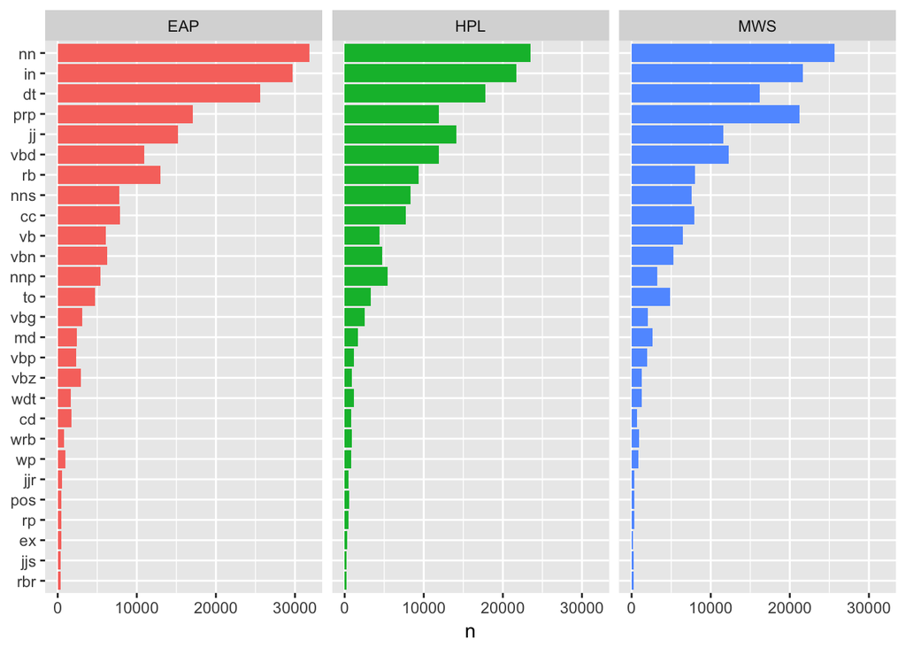

```r
# Counts number of times each author used each word.
author_pos <- count(group_by(spooky_pos, tag, author))

all_pos <- rename(count(group_by(spooky_pos, tag)), all = n)
author_pos <- left_join(author_pos, all_pos, by = "tag")
author_pos <- arrange(author_pos, desc(all))
author_pos <- ungroup(head(author_pos, 81))

ggplot(author_pos) +
  geom_col(aes(reorder(tag, all, FUN = min), n, fill = author)) +
  xlab(NULL) +
  coord_flip() +
  facet_wrap(~ author) +
  theme(legend.position = "none")
```